# Coronavirus in the World

# **Symptoms of Coronavirus**

- [Source](http://en.wikipedia.org/wiki/Coronavirus_disease_2019)

```python
symptoms={'symptom':['Fever',
        'Dry cough',
        'Fatigue',
        'Sputum production',
        'Shortness of breath',
        'Muscle pain',
        'Sore throat',
        'Headache',
        'Chills',
        'Nausea or vomiting',
        'Nasal congestion',
        'Diarrhoea',
        'Haemoptysis',
        'Conjunctival congestion'],'percentage':[87.9,67.7,38.1,33.4,18.6,14.8,13.9,13.6,11.4,5.0,4.8,3.7,0.9,0.8]}

symptoms=pd.DataFrame(data=symptoms,index=range(14))
symptoms
```

|  | symptom | percentage |
| --- | --- | --- |
| 0 | Fever | 87.9 |
| 1 | Dry cough | 67.7 |
| 2 | Fatigue | 38.1 |
| 3 | Sputum production | 33.4 |
| 4 | Shortness of breath | 18.6 |
| 5 | Muscle pain | 14.8 |
| 6 | Sore throat | 13.9 |
| 7 | Headache | 13.6 |
| 8 | Chills | 11.4 |
| 9 | Nausea or vomiting | 5.0 |
| 10 | Nasal congestion | 4.8 |
| 11 | Diarrhoea | 3.7 |
| 12 | Haemoptysis | 0.9 |
| 13 | Conjunctival congestion | 0.8 |

**Bar Chart**

```python
fig = px.bar(symptoms[['symptom', 'percentage']].sort_values('percentage', ascending=False),
             y="percentage", x="symptom", color='symptom',
             log_y=True, template='ggplot2', title='Symptom of  Coronavirus')
fig.show()
```

[interactive chart not shown]

**Pie Chart**

```python
fig = px.pie(symptoms,
             values="percentage",
             names="symptom",
             template="seaborn")
fig.update_traces(rotation=90, pull=0.05, textinfo="percent+label")
fig.show()
```

[interactive chart not shown]

**Tree Plot**

```python
fig = px.treemap(symptoms, path=['symptom'], values='percentage',
                  color='percentage', hover_data=['symptom'],
                  color_continuous_scale='Rainbow')
fig.show()
```

[interactive chart not shown]

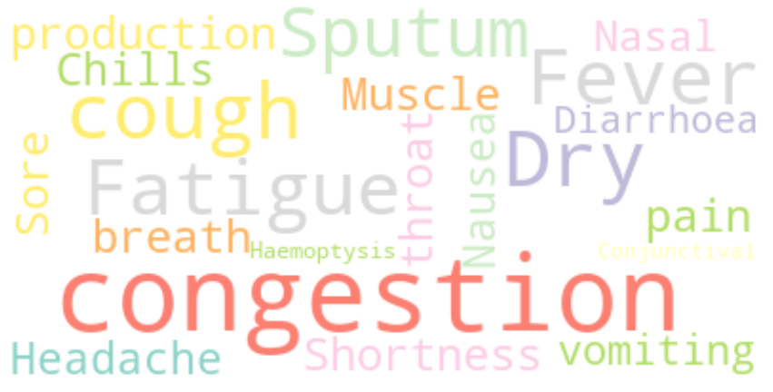

```python
from wordcloud import WordCloud, ImageColorGenerator
text = " ".join(str(each) for each in symptoms.symptom)
wordcloud = WordCloud(max_words=200,colormap='Set3', background_color="white").generate(text)
plt.figure(figsize=(10,6))
plt.figure(figsize=(15,10))
plt.imshow(wordcloud, interpolation='Bilinear')
plt.axis("off")
plt.figure(1,figsize=(12, 12))
plt.show()
```

```python
comp = pd.read_excel('COVID-19-3.27-top30-500.xlsx') #Read excel file to dataframe
# print(comp)
```

```python
df_patient = pd.read_csv("patient.csv")
# print(df_patient)
df_route = pd.read_csv("route.csv")
# print(df_route)
```

```python
weather = pd.read_csv("Weather.csv")
print(weather)
```

```
        code          province        date  avg_temp  min_temp  max_temp  \
0      10000             Seoul  2016-01-01       1.2      -3.3       4.0
1      11000             Busan  2016-01-01       5.3       1.1      10.9
2      12000             Daegu  2016-01-01       1.7      -4.0       8.0
3      13000           Gwangju  2016-01-01       3.2      -1.5       8.1
4      14000           Incheon  2016-01-01       3.1      -0.4       5.7
...      ...               ...         ...       ...       ...       ...
25130  50000      Jeollabuk-do  2020-04-19      11.2       8.0      16.1
25131  51000      Jeollanam-do  2020-04-19      12.0      10.6      13.4
25132  60000  Gyeongsangbuk-do  2020-04-19      10.2       5.5      15.0
25133  61000  Gyeongsangnam-do  2020-04-19      11.1       9.6      14.2
25134  70000           Jeju-do  2020-04-19      13.3      11.0      15.6

       precipitation  max_wind_speed  most_wind_direction  \
0                0.0             3.5                 90.0
```

[output cut: 25 more lines]

# **Looking into patient data**

```python
df_patient.head()
```

|  | id | sex | birth_year | country | region | group | infection_reason | infection_order | infected_by | contact_number | confirmed_date | released_date | deceased_date | state |
| --- | --- | --- | --- | --- | --- | --- | --- | --- | --- | --- | --- | --- | --- | --- |
| 0 | 1 | female | 1984.0 | China | filtered at airport | NaN | visit to Wuhan | 1.0 | NaN | 45.0 | 2020-01-20 | 2020-02-06 | NaN | released |
| 1 | 2 | male | 1964.0 | Korea | filtered at airport | NaN | visit to Wuhan | 1.0 | NaN | 75.0 | 2020-01-24 | 2020-02-05 | NaN | released |
| 2 | 3 | male | 1966.0 | Korea | capital area | NaN | visit to Wuhan | 1.0 | NaN | 16.0 | 2020-01-26 | 2020-02-12 | NaN | released |
| 3 | 4 | male | 1964.0 | Korea | capital area | NaN | visit to Wuhan | 1.0 | NaN | 95.0 | 2020-01-27 | 2020-02-09 | NaN | released |
| 4 | 5 | male | 1987.0 | Korea | capital area | NaN | visit to Wuhan | 1.0 | NaN | 31.0 | 2020-01-30 | 2020-03-02 | NaN | released |

1. **id** the ID of the patient (n-th confirmed patient)
2. **sex** the sex of the patient
3. **birth_year** the birth year of the patient
4. **country** the country of the patient
5. **region** the region of the patient
6. **group** the collective infection
7. **infection_reason** the reason of infection
8. **infection_order** the order of infection
9. **infected_by** the ID of who has infected the patient
10. **contact_number** the number of contacts with people
11. **confirmed_date** the date of confirmation
12. **released_date** the date of discharge
13. **deceased_date** the date of decease
14. **state** isolated / released / deceased

**Checking null value**

```python
df_patient.isna().sum()
```

```
id                     0
sex                 4945
birth_year          4958
country                0
region              4957
group               5247
infection_reason    5188
infection_order     5293
infected_by         5258
contact_number      5281
confirmed_date         0
released_date       5296
deceased_date       5308
state                  0
dtype: int64
```

```python
df_patient['birth_year'] = df_patient.birth_year.fillna(0.0).astype(int)
# print(df_patient['birth_year'])
df_patient['birth_year'] = df_patient['birth_year'].map(lambda val: val if val > 0 else np.nan)
# print(df_patient['birth_year'])
```

```python
df_patient.confirmed_date = pd.to_datetime(df_patient.confirmed_date)
daily_count = df_patient.groupby(df_patient.confirmed_date).id.count()
print(daily_count)
accumulated_count = daily_count.cumsum()
# print(accumulated_count)
```

[output not shown]

[output cut: 42 more lines]

```
2020-02-19      26
2020-02-20      39
2020-02-21     100
2020-02-22     229
2020-02-23     169
2020-02-24     231
2020-02-25     143
2020-02-26     285
2020-02-27     505
2020-02-28     571
2020-02-29     813
2020-03-01    1062
2020-03-02     600
2020-03-03     516
Name: id, dtype: int64
```

**Age**

```python
df_patient['age'] = 2020 - df_patient['birth_year']
df_patient['age'].head()
```

```
0    36.0
1    56.0
2    54.0
3    56.0
4    33.0
Name: age, dtype: float64
```

**Age Range**

```python
import math
def group_age(age):
    if age >= 0: # not NaN
        if age % 10 != 0:
            lower = int(math.floor(age / 10.0)) * 10
            upper = int(math.ceil(age / 10.0)) * 10 - 1
            return f"{lower}-{upper}"
        else:
            lower = int(age)
            upper = int(age + 9)
            return f"{lower}-{upper}"
    return "Unknown"


df_patient["age_range"] = df_patient["age"].apply(group_age)
df_patient["age_range"].head()
print(df_patient["age_range"])
```

```
0         30-39
1         50-59
2         50-59
3         50-59
4         30-39
         ...
5323    Unknown
5324    Unknown
5325    Unknown
5326    Unknown
5327    Unknown
Name: age_range, Length: 5328, dtype: object
```

```python
patient=df_patient
# print(patient)
```

**Preprocessing**

```python
date_cols = ["confirmed_date", "released_date", "deceased_date"]
for col in date_cols:
    patient[col] = pd.to_datetime(patient[col])
```

```python
patient["time_to_release_since_confirmed"] = patient["released_date"] - patient["confirmed_date"]

patient["time_to_death_since_confirmed"] = patient["deceased_date"] - patient["confirmed_date"]

patient["duration_since_confirmed"] = patient[["time_to_release_since_confirmed", "time_to_death_since_confirmed"]].min(axis=1)
patient["duration_days"] = patient["duration_since_confirmed"].dt.days
# print(patient)
age_ranges = sorted(set([ar for ar in patient["age_range"] if ar != "Unknown"]))
patient["state_by_gender"] = patient["state"] + "_" + patient["sex"]
```

# **Confirmed Count**

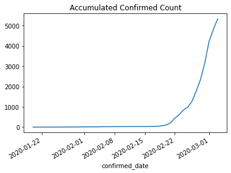

```python
accumulated_count.plot()
plt.title('Accumulated Confirmed Count');
```

# **Time series Analysis**

```python
time = pd.read_csv("covid_19_data.csv")
# print(time)
```

```python
# time = time[time['Country/Region']=='South Korea']
time = time[time['Country/Region']=='Bangladesh']
```

```python
time = time.tail(14)
# print(time)
```

```python
time
```

|  | SNo | ObservationDate | Province/State | Country/Region | Last Update | Confirmed | Deaths | Recovered |
| --- | --- | --- | --- | --- | --- | --- | --- | --- |
| 12579 | 12580 | 04/07/2020 | NaN | Bangladesh | 2020-04-07 23:11:31 | 164.0 | 17.0 | 33.0 |
| 12899 | 12900 | 04/08/2020 | NaN | Bangladesh | 2020-04-08 22:59:00 | 218.0 | 20.0 | 33.0 |
| 13219 | 13220 | 04/09/2020 | NaN | Bangladesh | 2020-04-09 23:09:19 | 330.0 | 21.0 | 33.0 |
| 13539 | 13540 | 04/10/2020 | NaN | Bangladesh | 2020-04-10 23:01:43 | 424.0 | 27.0 | 33.0 |
| 13860 | 13861 | 04/11/2020 | NaN | Bangladesh | 2020-04-11 22:52:46 | 482.0 | 30.0 | 36.0 |
| 14181 | 14182 | 04/12/2020 | NaN | Bangladesh | 2020-04-12 23:25:00 | 621.0 | 34.0 | 39.0 |
| 14501 | 14502 | 04/13/2020 | NaN | Bangladesh | 2020-04-13 23:15:42 | 803.0 | 39.0 | 42.0 |
| 14821 | 14822 | 04/14/2020 | NaN | Bangladesh | 2020-04-14 23:41:11 | 1012.0 | 46.0 | 42.0 |
| 15141 | 15142 | 04/15/2020 | NaN | Bangladesh | 2020-04-15 23:04:26 | 1231.0 | 50.0 | 49.0 |
| 15461 | 15462 | 04/16/2020 | NaN | Bangladesh | 2020-04-16 23:38:19 | 1572.0 | 60.0 | 49.0 |
| 15781 | 15782 | 04/17/2020 | NaN | Bangladesh | 2020-04-17 23:38:48 | 1838.0 | 75.0 | 58.0 |
| 16101 | 16102 | 04/18/2020 | NaN | Bangladesh | 2020-04-18 22:40:18 | 2144.0 | 84.0 | 66.0 |
| 16421 | 16422 | 04/19/2020 | NaN | Bangladesh | 2020-04-19 23:49:05 | 2456.0 | 91.0 | 75.0 |
| 16741 | 16742 | 04/20/2020 | NaN | Bangladesh | 2020-04-20 23:44:50 | 2948.0 | 101.0 | 85.0 |

# **Confrim vs Recovery vs Death**

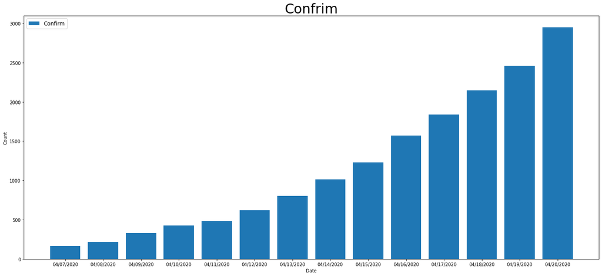

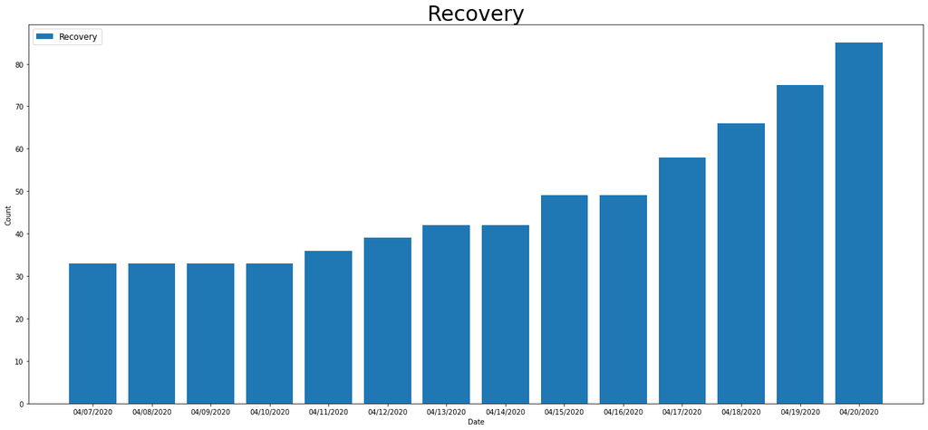

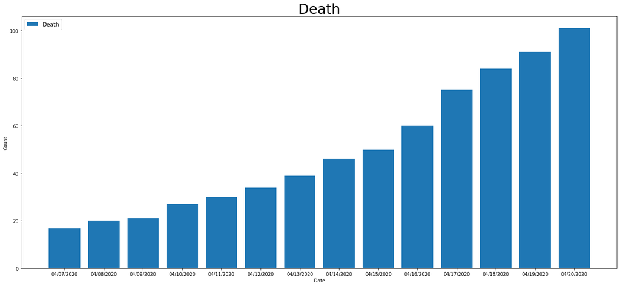

```python
plt.figure(figsize=(23,10))
plt.bar(time.ObservationDate, time.Confirmed,label="Confirm")
plt.xlabel('Date')
plt.ylabel("Count")
plt.legend(frameon=True, fontsize=12)
plt.title('Confrim',fontsize=30)
plt.show()


plt.figure(figsize=(23,10))
plt.bar(time.ObservationDate, time.Recovered,label="Recovery")
plt.xlabel('Date')
plt.ylabel("Count")
plt.legend(frameon=True, fontsize=12)
plt.title('Recovery',fontsize=30)
plt.show()

plt.figure(figsize=(23,10))

plt.bar(time.ObservationDate, time.Deaths,label="Death")
plt.xlabel('Date')
plt.ylabel("Count")
plt.legend(frameon=True, fontsize=12)
plt.title('Death',fontsize=30)
plt.show()
```

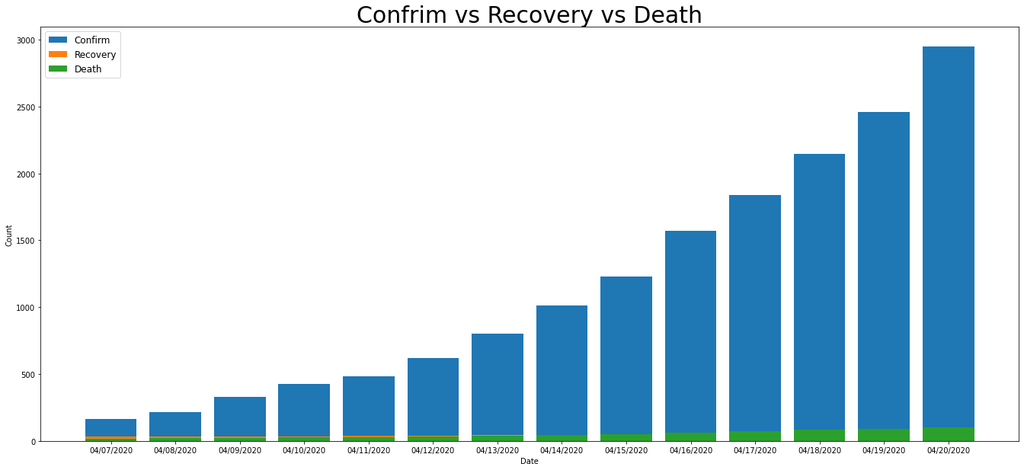

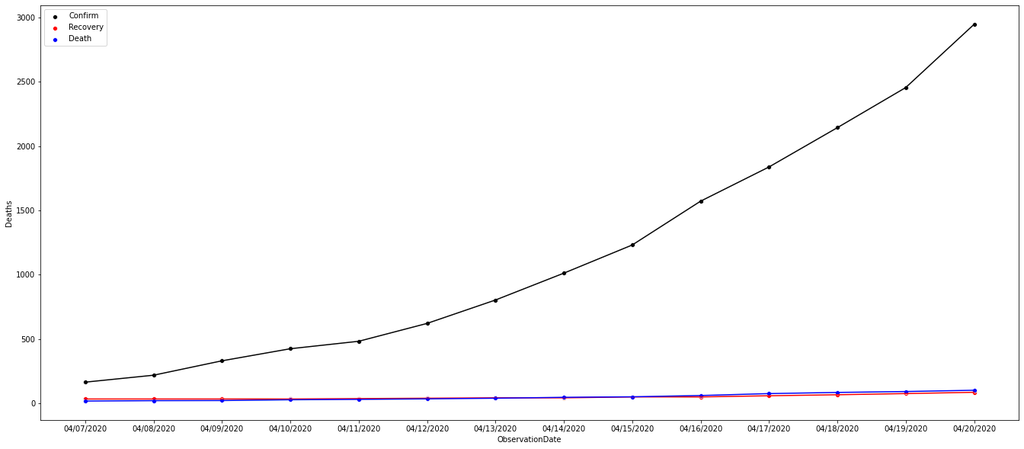

```python
plt.figure(figsize=(23,10))
plt.bar(time.ObservationDate, time.Confirmed,label="Confirm")
plt.bar(time.ObservationDate, time.Recovered,label="Recovery")
plt.bar(time.ObservationDate, time.Deaths,label="Death")
plt.xlabel('Date')
plt.ylabel("Count")
plt.legend(frameon=True, fontsize=12)
plt.title('Confrim vs Recovery vs Death',fontsize=30)
plt.show()

f, ax = plt.subplots(figsize=(23,10))
ax=sns.scatterplot(x="ObservationDate", y="Confirmed", data=time,
             color="black",label = "Confirm")
ax=sns.scatterplot(x="ObservationDate", y="Recovered", data=time,
             color="red",label = "Recovery")
ax=sns.scatterplot(x="ObservationDate", y="Deaths", data=time,
             color="blue",label = "Death")
plt.plot(time.ObservationDate,time.Confirmed,zorder=1,color="black")
plt.plot(time.ObservationDate,time.Recovered,zorder=1,color="red")
plt.plot(time.ObservationDate,time.Deaths,zorder=1,color="blue")
```

```python
# print(time['Confirmed'])
Total_confirmed = time['Confirmed'].max()
Total_recovered = time['Recovered'].max()
Total_death = time['Deaths'].max()
data = [['Confirmed', Total_confirmed], ['Recovered', Total_recovered], ['Death', Total_death]]
df = pd.DataFrame(data, columns = ['state', 'count'])
# print(df)
fig = px.pie(df,
             values="count",
             names="state",
             title="State of Patient",
             template="seaborn")
fig.update_traces(rotation=90, pull=0.05, textinfo="percent+label")
fig.show()
```

[interactive chart not shown]

# **Daily Growth**

```python
time['Confirmed_new'] = time['Confirmed']-time['Confirmed'].shift(1)
print(time['Confirmed_new'])
time['Recovered_new'] = time['Recovered']-time['Recovered'].shift(1)
time['Deaths_new'] = time['Deaths']-time['Deaths'].shift(1)
```

```
12579      NaN
12899     54.0
13219    112.0
13539     94.0
13860     58.0
14181    139.0
14501    182.0
14821    209.0
15141    219.0
15461    341.0
15781    266.0
16101    306.0
16421    312.0
16741    492.0
Name: Confirmed_new, dtype: float64
```

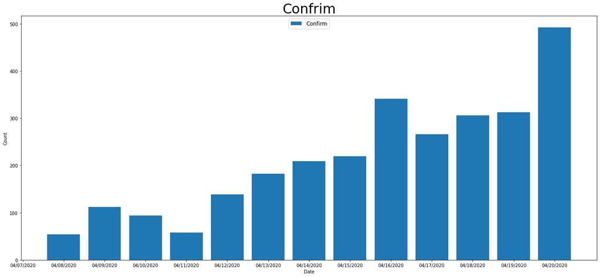

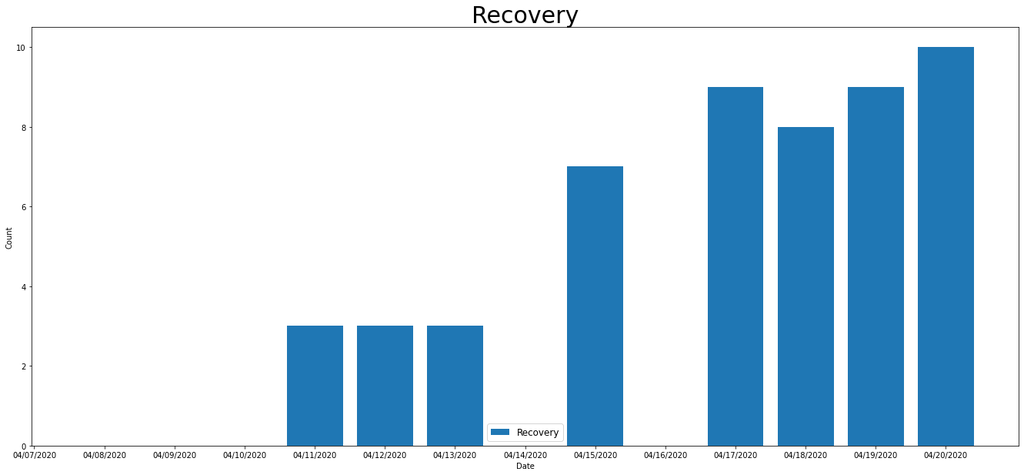

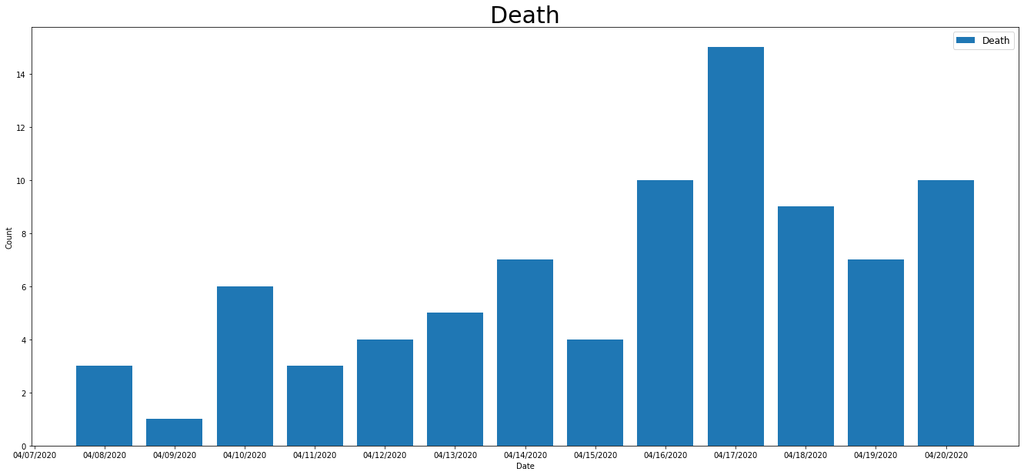

```python
plt.figure(figsize=(23,10))
plt.bar(time.ObservationDate, time.Confirmed_new,label="Confirm")
plt.xlabel('Date')
plt.ylabel("Count")
plt.legend(frameon=True, fontsize=12)
plt.title('Confrim',fontsize=30)
plt.show()


plt.figure(figsize=(23,10))
plt.bar(time.ObservationDate, time.Recovered_new,label="Recovery")
plt.xlabel('Date')
plt.ylabel("Count")
plt.legend(frameon=True, fontsize=12)
plt.title('Recovery',fontsize=30)
plt.show()

plt.figure(figsize=(23,10))

plt.bar(time.ObservationDate, time.Deaths_new,label="Death")
plt.xlabel('Date')
plt.ylabel("Count")
plt.legend(frameon=True, fontsize=12)
plt.title('Death',fontsize=30)
plt.show()
```

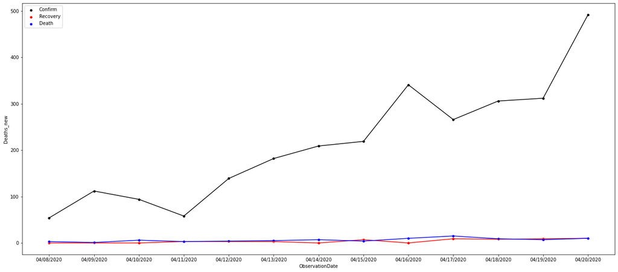

```python
f, ax = plt.subplots(figsize=(23,10))
ax=sns.scatterplot(x="ObservationDate", y="Confirmed_new", data=time,
             color="black",label = "Confirm")
ax=sns.scatterplot(x="ObservationDate", y="Recovered_new", data=time,
             color="red",label = "Recovery")
ax=sns.scatterplot(x="ObservationDate", y="Deaths_new", data=time,
             color="blue",label = "Death")
plt.plot(time.ObservationDate,time.Confirmed_new,zorder=1,color="black")
plt.plot(time.ObservationDate,time.Recovered_new,zorder=1,color="red")
plt.plot(time.ObservationDate,time.Deaths_new,zorder=1,color="blue")
```

```python
global_data = time
```

# **Growth Rate and Ratio**

```python
# This functions smooths data, thanks to Dan Pearson. We will use it to smooth the data for growth factor.
def smoother(inputdata,w,imax):
    data = 1.0*inputdata
    data = data.replace(np.nan,1)
    data = data.replace(np.inf,1)
    #print(data)
    smoothed = 1.0*data
    normalization = 1
    for i in range(-imax,imax+1):
        if i==0:
            continue
        smoothed += (w**abs(i))*data.shift(i,axis=0)
        normalization += w**abs(i)
    smoothed /= normalization
    return smoothed

def growth_factor(confirmed):
    confirmed_iminus1 = confirmed.shift(1, axis=0)
    confirmed_iminus2 = confirmed.shift(2, axis=0)
    return (confirmed-confirmed_iminus1)/(confirmed_iminus1-confirmed_iminus2)

def growth_ratio(confirmed):
    confirmed_iminus1 = confirmed.shift(1, axis=0)
    return (confirmed/confirmed_iminus1)

# This is a function which plots (for in input country) the active, confirmed, and recovered cases, deaths, and the growth factor.
def plot_country_active_confirmed_recovered(country):

    # Plots Active, Confirmed, and Recovered Cases. Also plots deaths.
    country_data = global_data[global_data['Country/Region']==country]
    table = country_data.drop(['SNo','Province/State', 'Last Update'], axis=1)
    print(table)
    table['ActiveCases'] = table['Confirmed'] - table['Recovered'] - table['Deaths']
    table2 = pd.pivot_table(table, values=['ActiveCases','Confirmed', 'Recovered','Deaths'], index=['ObservationDate'], aggfunc=np.sum)
    table3 = table2.drop(['Deaths'], axis=1)

    # Growth Factor
    w = 0.5
    table2['GrowthFactor'] = growth_factor(table2['Confirmed'])
    table2['GrowthFactor'] = smoother(table2['GrowthFactor'],w,5)

    # 2nd Derivative
    table2['2nd_Derivative'] = np.gradient(np.gradient(table2['Confirmed'])) #2nd derivative
    table2['2nd_Derivative'] = smoother(table2['2nd_Derivative'],w,7)


    #Plot confirmed[i]/confirmed[i-1], this is called the growth ratio
    table2['GrowthRatio'] = growth_ratio(table2['Confirmed'])
    table2['GrowthRatio'] = smoother(table2['GrowthRatio'],w,5)

    #Plot the growth rate, we will define this as k in the logistic function presented at the beginning of this notebook.
    table2['GrowthRate']=np.gradient(np.log(table2['Confirmed']))
    table2['GrowthRate'] = smoother(table2['GrowthRate'],0.5,3)

    # horizontal line at growth rate 1.0 for reference
    x_coordinates = [1, 100]
    y_coordinates = [1, 1]
    f, ax = plt.subplots(figsize=(15,5))
    table2['Deaths'].plot(title='Deaths')
    plt.show()
    f, ax = plt.subplots(figsize=(15,5))
    table2['GrowthFactor'].plot(title='Growth Factor')
    plt.plot(x_coordinates, y_coordinates)
    plt.show()
    f, ax = plt.subplots(figsize=(15,5))
    table2['2nd_Derivative'].plot(title='2nd_Derivative')
    plt.show()
    f, ax = plt.subplots(figsize=(15,5))
    table2['GrowthRatio'].plot(title='Growth Ratio')
    plt.plot(x_coordinates, y_coordinates)
    plt.show()
    f, ax = plt.subplots(figsize=(15,5))
    table2['GrowthRate'].plot(title='Growth Rate')
    plt.show()

    return
```

```
      ObservationDate Country/Region  Confirmed  Deaths  Recovered  \
12579      04/07/2020     Bangladesh      164.0    17.0       33.0
12899      04/08/2020     Bangladesh      218.0    20.0       33.0
13219      04/09/2020     Bangladesh      330.0    21.0       33.0
13539      04/10/2020     Bangladesh      424.0    27.0       33.0
13860      04/11/2020     Bangladesh      482.0    30.0       36.0
14181      04/12/2020     Bangladesh      621.0    34.0       39.0
14501      04/13/2020     Bangladesh      803.0    39.0       42.0
14821      04/14/2020     Bangladesh     1012.0    46.0       42.0
15141      04/15/2020     Bangladesh     1231.0    50.0       49.0
15461      04/16/2020     Bangladesh     1572.0    60.0       49.0
15781      04/17/2020     Bangladesh     1838.0    75.0       58.0
16101      04/18/2020     Bangladesh     2144.0    84.0       66.0
16421      04/19/2020     Bangladesh     2456.0    91.0       75.0
16741      04/20/2020     Bangladesh     2948.0   101.0       85.0
```

[output cut: 16 more lines]

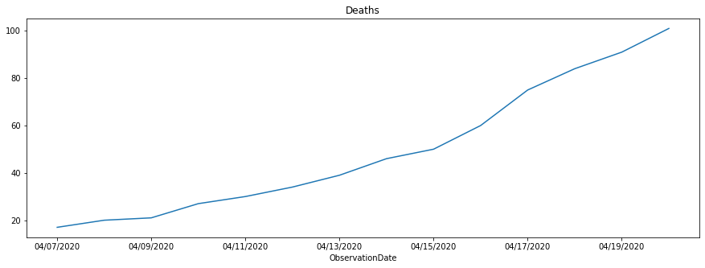

[figure not shown]

[figure not shown]

[figure not shown]

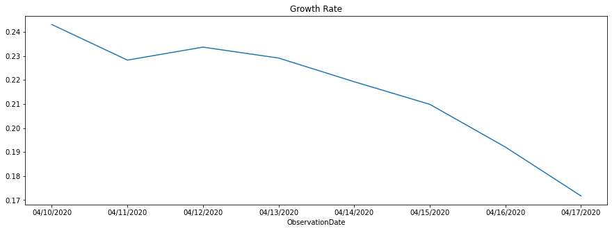

```python
# plot_country_active_confirmed_recovered('South Korea')
plot_country_active_confirmed_recovered('Bangladesh')
```

# **Current State of Patient**

```python
infected_patient = patient.shape[0]
print(infected_patient)
rp = patient.loc[patient["state"] == "released"].shape[0]
print(rp)
dp = patient.loc[patient["state"] == "deceased"].shape[0]
print(dp)
ip = patient.loc[patient["state"]== "isolated"].shape[0]
print(ip)
rp=rp/patient.shape[0]
dp=dp/patient.shape[0]
ip=ip/patient.shape[0]
print("The percentage of recovery is "+ str(rp*100) )
print("The percentage of deceased is "+ str(dp*100) )
print("The percentage of isolated is "+ str(ip*100) )
```

```
5328
35
20
5273
The percentage of recovery is 0.6569069069069069
The percentage of deceased is 0.37537537537537535
The percentage of isolated is 98.96771771771772
```

```python
states = pd.DataFrame(patient["state"].value_counts())
print(states)
states["status"] = states.index
print(states)
states.rename(columns={"state": "count"}, inplace=True)

fig = px.pie(states,
             values="count",
             names="status",
             title="Current state of patients",
             template="seaborn")
fig.update_traces(rotation=90, pull=0.05, textinfo="value+percent+label")
fig.show()
```

```
          state
isolated   5273
released     35
deceased     20
          state    status
isolated   5273  isolated
released     35  released
deceased     20  deceased
```

[interactive chart not shown]

**People who released**

```python
released = df_patient[df_patient.state == 'released']
released.head()
```

|  | id | sex | birth_year | country | region | group | infection_reason | infection_order | infected_by | contact_number | ... | released_date | deceased_date | state | age | age_range | time_to_release_since_confirmed | time_to_death_since_confirmed | duration_since_confirmed | duration_days | state_by_gender |
| --- | --- | --- | --- | --- | --- | --- | --- | --- | --- | --- | --- | --- | --- | --- | --- | --- | --- | --- | --- | --- | --- |
| 0 | 1 | female | 1984.0 | China | filtered at airport | NaN | visit to Wuhan | 1.0 | NaN | 45.0 | ... | 2020-02-06 | NaT | released | 36.0 | 30-39 | 17 days | NaT | 17 days | 17.0 | released_female |
| 1 | 2 | male | 1964.0 | Korea | filtered at airport | NaN | visit to Wuhan | 1.0 | NaN | 75.0 | ... | 2020-02-05 | NaT | released | 56.0 | 50-59 | 12 days | NaT | 12 days | 12.0 | released_male |
| 2 | 3 | male | 1966.0 | Korea | capital area | NaN | visit to Wuhan | 1.0 | NaN | 16.0 | ... | 2020-02-12 | NaT | released | 54.0 | 50-59 | 17 days | NaT | 17 days | 17.0 | released_male |
| 3 | 4 | male | 1964.0 | Korea | capital area | NaN | visit to Wuhan | 1.0 | NaN | 95.0 | ... | 2020-02-09 | NaT | released | 56.0 | 50-59 | 13 days | NaT | 13 days | 13.0 | released_male |
| 4 | 5 | male | 1987.0 | Korea | capital area | NaN | visit to Wuhan | 1.0 | NaN | 31.0 | ... | 2020-03-02 | NaT | released | 33.0 | 30-39 | 32 days | NaT | 32 days | 32.0 | released_male |

5 rows × 21 columns

**People who are in isolated state**

```python
isolated_state = df_patient[df_patient.state == 'isolated']
isolated_state.head()
```

|  | id | sex | birth_year | country | region | group | infection_reason | infection_order | infected_by | contact_number | ... | released_date | deceased_date | state | age | age_range | time_to_release_since_confirmed | time_to_death_since_confirmed | duration_since_confirmed | duration_days | state_by_gender |
| --- | --- | --- | --- | --- | --- | --- | --- | --- | --- | --- | --- | --- | --- | --- | --- | --- | --- | --- | --- | --- | --- |
| 24 | 25 | female | 1946.0 | Korea | capital area | NaN | contact with patient | 2.0 | 27.0 | 12.0 | ... | NaT | NaT | isolated | 74.0 | 70-79 | NaT | NaT | NaT | NaN | isolated_female |
| 25 | 26 | male | 1968.0 | Korea | capital area | NaN | contact with patient | 1.0 | 27.0 | 0.0 | ... | NaT | NaT | isolated | 52.0 | 50-59 | NaT | NaT | NaT | NaN | isolated_male |
| 26 | 27 | female | 1982.0 | China | capital area | NaN | visit to China | 1.0 | NaN | 40.0 | ... | NaT | NaT | isolated | 38.0 | 30-39 | NaT | NaT | NaT | NaN | isolated_female |
| 28 | 29 | male | 1938.0 | Korea | capital area | NaN | contact with patient | 4.0 | 83.0 | 117.0 | ... | NaT | NaT | isolated | 82.0 | 80-89 | NaT | NaT | NaT | NaN | isolated_male |
| 29 | 30 | female | 1952.0 | Korea | capital area | NaN | contact with patient | 5.0 | 29.0 | 27.0 | ... | NaT | NaT | isolated | 68.0 | 60-69 | NaT | NaT | NaT | NaN | isolated_female |

5 rows × 21 columns

**Patient who died**

```python
dead = df_patient[df_patient.state == 'deceased']
dead.head()
```

|  | id | sex | birth_year | country | region | group | infection_reason | infection_order | infected_by | contact_number | ... | released_date | deceased_date | state | age | age_range | time_to_release_since_confirmed | time_to_death_since_confirmed | duration_since_confirmed | duration_days | state_by_gender |
| --- | --- | --- | --- | --- | --- | --- | --- | --- | --- | --- | --- | --- | --- | --- | --- | --- | --- | --- | --- | --- | --- |
| 37 | 38 | female | 1963.0 | Korea | Daegu | NaN | NaN | NaN | NaN | NaN | ... | NaT | 2020-02-23 | deceased | 57.0 | 50-59 | NaT | 5 days | 5 days | 5.0 | deceased_female |
| 53 | 54 | male | 1963.0 | Korea | Gyeongsangbuk-do | Cheongdo Daenam Hospital | NaN | NaN | NaN | NaN | ... | NaT | 2020-02-23 | deceased | 57.0 | 50-59 | NaT | 4 days | 4 days | 4.0 | deceased_male |
| 54 | 55 | male | 1961.0 | Korea | Gyeongsangbuk-do | Cheongdo Daenam Hospital | NaN | NaN | NaN | NaN | ... | NaT | 2020-02-23 | deceased | 59.0 | 50-59 | NaT | 4 days | 4 days | 4.0 | deceased_male |
| 102 | 103 | male | 1957.0 | Korea | Gyeongsangbuk-do | Cheongdo Daenam Hospital | NaN | NaN | NaN | NaN | ... | NaT | 2020-02-19 | deceased | 63.0 | 60-69 | NaT | -1 days | -1 days | -1.0 | deceased_male |
| 106 | 107 | male | 1953.0 | Korea | Gyeongsangbuk-do | Cheongdo Daenam Hospital | NaN | NaN | NaN | NaN | ... | NaT | 2020-02-24 | deceased | 67.0 | 60-69 | NaT | 3 days | 3 days | 3.0 | deceased_male |

5 rows × 21 columns

# **Age distribution of the released**

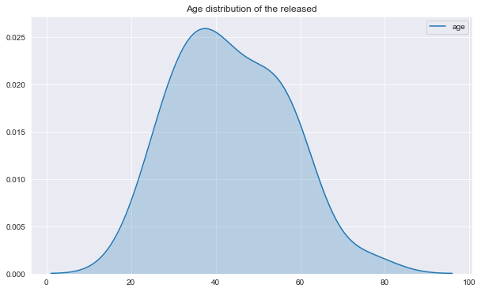

```python
plt.figure(figsize=(10,6))
sns.set_style("darkgrid")
plt.title("Age distribution of the released")
sns.kdeplot(data=released['age'], shade=True)
```

```python
agr = released[released.age_range!="Unknown"]
fig = px.pie(agr,
             names="age_range",
             title="Age of released person",
             template="seaborn")
fig.update_traces(rotation=90, pull=0.05, textinfo="percent+label")
fig.show()
```

[interactive chart not shown]

# **Age distribution of isolated person**

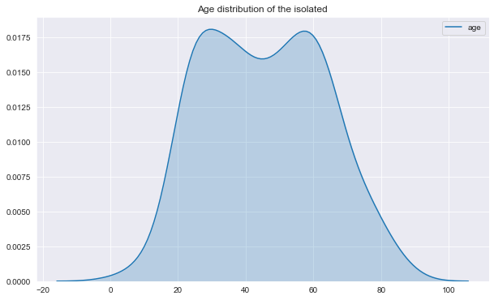

```python
plt.figure(figsize=(10,6))
sns.set_style("darkgrid")
plt.title("Age distribution of the isolated")
sns.kdeplot(data=isolated_state['age'], shade=True)
```

```python
agi = isolated_state[isolated_state.age_range!="Unknown"]
fig = px.pie(agi,
             names="age_range",
             title="Age of isolated person",
             template="seaborn")
fig.update_traces(rotation=90, pull=0.05, textinfo="percent+label")
fig.show()
```

[interactive chart not shown]

# **Age distribution of death**

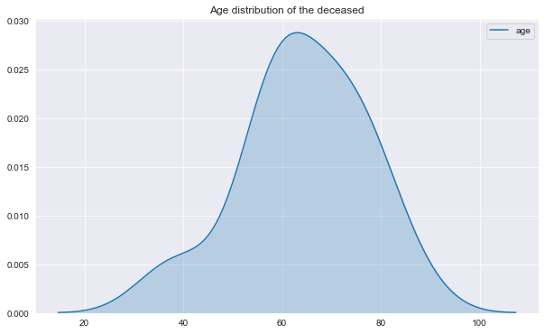

```python
plt.figure(figsize=(10,6))
sns.set_style("darkgrid")
plt.title("Age distribution of the deceased")
sns.kdeplot(data=dead['age'], shade=True)
```

```python
agd = dead[dead.age_range!="Unknown"]
fig = px.pie(agd,
             names="age_range",
             title="Age of Dead person",
             template="seaborn")
fig.update_traces(rotation=90, pull=0.05, textinfo="percent+label")
fig.show()
```

[interactive chart not shown]

```
                                  ** Age distribution of deceased **
```

```python
male_dead = dead[dead.sex=='male']
female_dead = dead[dead.sex=='female']
```

# **Age distribution of death by gender**

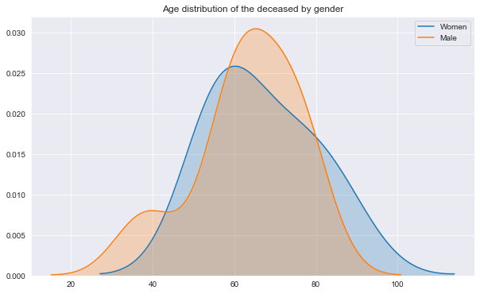

```python
plt.figure(figsize=(10,6))
sns.set_style("darkgrid")
plt.title("Age distribution of the deceased by gender")
sns.kdeplot(data=female_dead['age'], label="Women", shade=True)
sns.kdeplot(data=male_dead['age'],label="Male" ,shade=True)
```

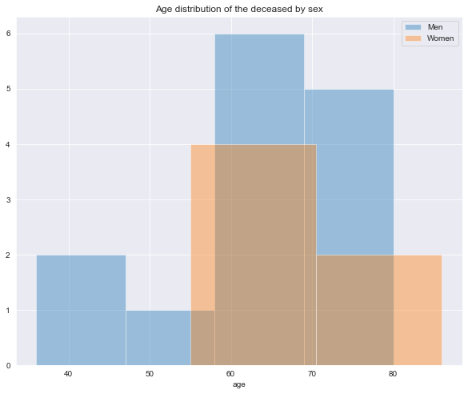

```python
plt.figure(figsize=(10,8))
sns.set_style("darkgrid")
sns.distplot(a=male_dead['age'], label="Men", kde=False)
sns.distplot(a=female_dead['age'], label="Women", kde=False)
plt.title("Age distribution of the deceased by sex")
plt.legend()
```

```
                                **Gender distribution of deceased **
```

The graph shows the age distribution of deceased gender where men are more likely to die from coronavirus than women. New research has found that men, particularly middle-aged and older men, are having a harder time fighting off the virus than women. Chinese researchers found that while the infection rate among men and women is the same, the death rate among men is 2.8% compared with 1.7% for women. As there are a few reasons men are more likely to die from the new coronavirus. Women have a heightened immune response. During Middle East respiratory syndrome coronavirus 32% of men died of the infection compared with 25.8% of women.

**Comparison of released and deceased by age**

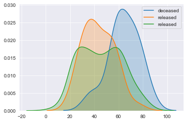

```python
sns.kdeplot(data=dead['age'],label='deceased', shade=True)
sns.kdeplot(data=released['age'],label='released', shade=True)
sns.kdeplot(data=isolated_state['age'],label='released', shade=True)
```

# **Death by gender**

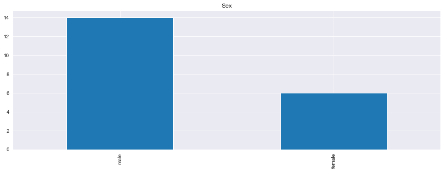

```python
plt.figure(figsize=(15, 5))
plt.title('Sex')
dead.sex.value_counts().plot.bar();
```

```python
fig = px.pie( values=dead.groupby(['sex']).size().values,names=dead.groupby(['sex']).size().index)
fig.update_layout(
    font=dict(
        size=15,
        color="#242323"
    )
    )

py.iplot(fig)
```

[interactive chart not shown]

# **Isolation by gender**

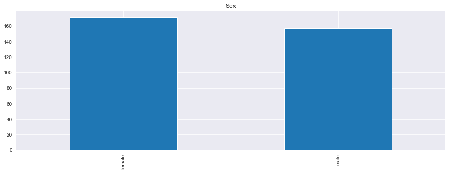

```python
plt.figure(figsize=(15, 5))
plt.title('Sex')
isolated_state.sex.value_counts().plot.bar();
```

```python
fig = px.pie( values=isolated_state.groupby(['sex']).size().values,names=isolated_state.groupby(['sex']).size().index)
fig.update_layout(
    font=dict(
        size=15,
        color="#242323"
    )
    )

py.iplot(fig)
```

[interactive chart not shown]

# **Recovery by gender**

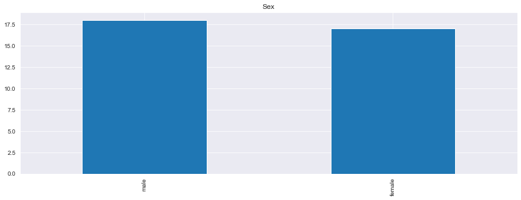

```python
plt.figure(figsize=(15, 5))
plt.title('Sex')
released.sex.value_counts().plot.bar();
```

```python
fig = px.pie( values=released.groupby(['sex']).size().values,names=released.groupby(['sex']).size().index)
fig.update_layout(
    font=dict(
        size=15,
        color="#242323"
    )
    )

py.iplot(fig)
```

[interactive chart not shown]

# **Reason for the infection**

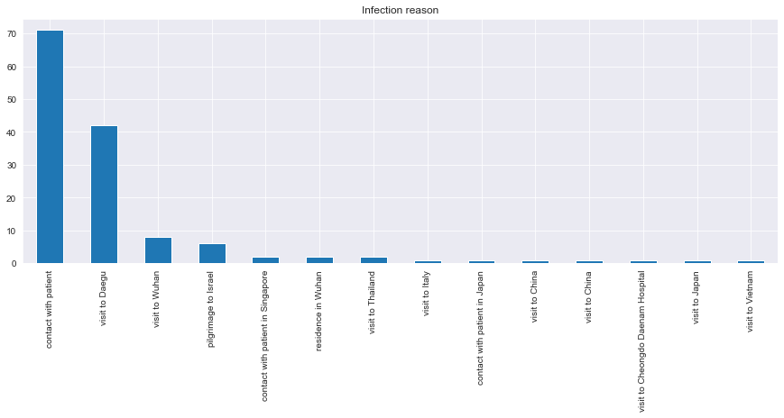

```python
plt.figure(figsize=(15,5))
plt.title('Infection reason')
df_patient.infection_reason.value_counts().plot.bar();
```

```python
fig = px.pie( values=df_patient.groupby(['infection_reason']).size().values,names=df_patient.groupby(['infection_reason']).size().index)
fig.update_layout(
    font=dict(
        size=15,
        color="#242323"
    )
    )

py.iplot(fig)
```

[interactive chart not shown]

```python
inf_rsn =  df_patient['infection_reason']
inf_rsn  = inf_rsn.dropna()
```

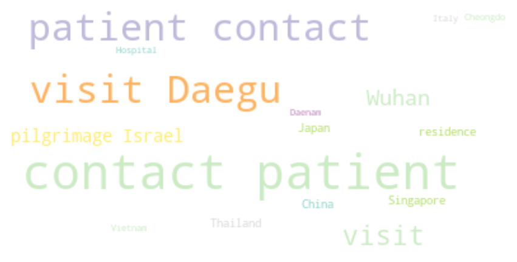

```python
from wordcloud import WordCloud, ImageColorGenerator
text = " ".join(str(each) for each in inf_rsn)
wordcloud = WordCloud(max_words=200,colormap='Set3', background_color="white").generate(text)
plt.figure(figsize=(10,6))
plt.figure(figsize=(15,10))
plt.imshow(wordcloud, interpolation='Bilinear')
plt.axis("off")
plt.figure(1,figsize=(12, 12))
plt.show()
```

**There are many effective reasons for the coronavirus infection. There is no specific antiviral treatment recommended for COVID-19. People with COVID-19 should receive supportive care to help relieve symptoms. For severe cases, treatment should include care to support vital organ functions.People who think they may have been exposed to COVID-19 should contact their healthcare provider immediately. According to the dataset the major reason for the infection is being in contact with patients. There are so many different reasons for the cause of infection which are visits to countries and regions like daegu, wuhan, thailand, china, vietnam, italy.**

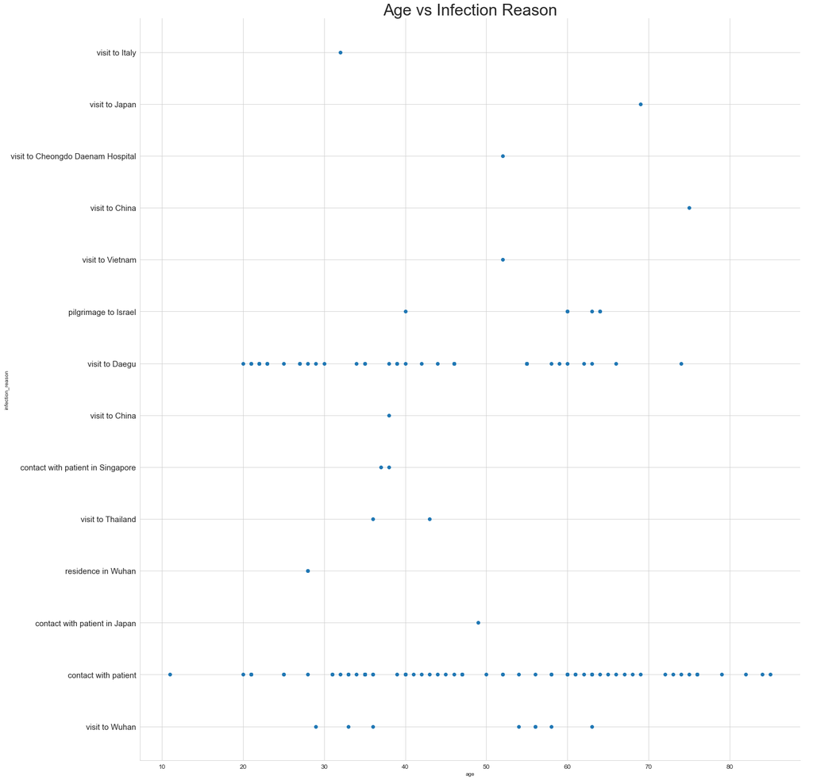

```python
sns.set_style("whitegrid")
sns.FacetGrid(df_patient,  size = 20)\
.map(plt.scatter, 'age', 'infection_reason')\
.add_legend()
plt.title('Age vs Infection Reason',fontsize=30)
plt.xticks(fontsize=12)
plt.yticks(fontsize=15)
plt.show()
```

# **State of Patient**

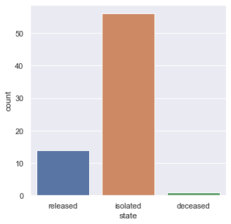

```python
sns.set(rc={'figure.figsize':(5,5)})
sns.countplot(x=df_patient['state'].loc[
    (df_patient['infection_reason']=='contact with patient')
])
```

```python
fig = px.pie( values=df_patient.groupby(['state']).size().values,names=df_patient.groupby(['state']).size().index)
fig.update_layout(
    font=dict(
        size=15,
        color="#242323"
    )
    )

py.iplot(fig)
```

[interactive chart not shown]

**State of male patient**

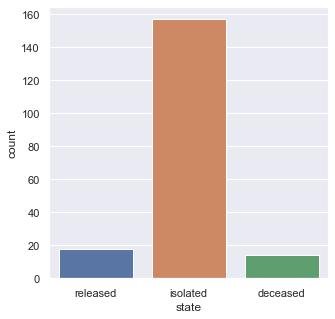

```python
sns.set(rc={'figure.figsize':(5,5)})
sns.countplot(x=df_patient['state'].loc[(df_patient['sex']=="male")])
```

**State of female patient**

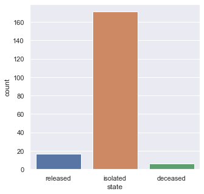

```python
sns.set(rc={'figure.figsize':(5,5)})
sns.countplot(x=df_patient['state'].loc[(df_patient['sex']=="female")])
```

# **State of patient(male and female) vs age**

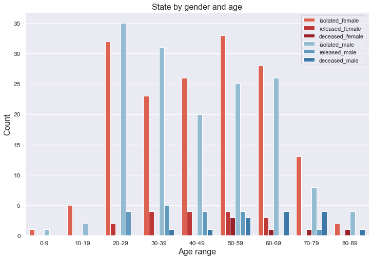

```python
age_gender_hue_order =["isolated_female", "released_female", "deceased_female",
                       "isolated_male", "released_male", "deceased_male"]
custom_palette = sns.color_palette("Reds")[3:6] + sns.color_palette("Blues")[2:5]

plt.figure(figsize=(12, 8))
sns.countplot(x = "age_range",
              hue="state_by_gender",
              order=age_ranges,
              hue_order=age_gender_hue_order,
              palette=custom_palette,
              data=patient)
plt.title("State by gender and age", fontsize=16)
plt.xlabel("Age range", fontsize=16)
plt.ylabel("Count", fontsize=16)
plt.xticks(fontsize=12)
plt.yticks(fontsize=12)
plt.legend(loc="upper right")
plt.show()
```